# Pré-traitement avancé des données

Daniel Pont

04/07/2020

# Pré-traitement avancé des données

## 1. Intérêt du package vtreat

vtreat est un package R conçu pour préparer des données du monde réel pour un apprentissage supervisé ou une modélisation prédictive. Il est conçu pour traiter de nombreux problèmes courants, de sorte que le data scientist n’a pas à le faire :

- Valeurs manquantes dans les variables numériques
- Valeurs extrêmes ou hors plage dans les variables numériques
- Valeurs manquantes dans les variables catégorielles
- Valeurs rares dans les données catégorielles
- Valeurs catégorielles nouvelles (valeurs vues lors des tests ou de l’application, mais pas pendant l’apprentissage)
- Données catégoriques avec de très nombreuses valeurs possibles
- Surapprentissage en raison d’un grand nombre de variables

## 2. KDD et la coupe KDD 2009

La coupe KDD 2009 a fourni un ensemble de données sur la gestion de la relation client. Les données de ce concours ont fourni 230 informations sur 50 000 comptes de carte de crédit. À partir de ces fonctionnalités, l’un des objectifs du concours était de prédire l’annulation du compte (appelé “churn” - désabonnement). L’utilisation basique de vtreat consisteà diviser les données en trois parties: un ensemble pour l’apprentissage du traitement des données, un pour la modélisation et un troisième pour estimer la qualité du modèle sur les nouvelles données.

### 2.1 Chargement des données

```r
d <- read.table('data/orange_small_train.data.gz',
                  header = TRUE,
                  sep = '\t',
                  na.strings = c('NA', ''))

churn <- read.table('data/orange_small_train_churn.labels.txt',header = FALSE, sep = '\t')
d$churn <- churn$V1

set.seed(729375)
rgroup <- base::sample(c('train', 'calibrate', 'test'),
                        nrow(d),
                        prob = c(0.8, 0.1, 0.1),
                        replace = TRUE)

dTrain <- d[rgroup == 'train', , drop = FALSE]
dCal <- d[rgroup == 'calibrate', , drop = FALSE]
dTrainAll <- d[rgroup %in% c('train', 'calibrate'), , drop = FALSE]
dTest <- d[rgroup == 'test', , drop = FALSE]

outcome <- 'churn'
vars <- setdiff(colnames(dTrainAll), outcome)
rm(list=c('d', 'churn', 'rgroup'))
```

Avant de commencer la modélisation, nous devons examiner la distribution du résultat ;

```r
outcome_summary <- table(
                      churn = dTrain[, outcome],
                      useNA = 'ifany')
knitr::kable(outcome_summary)
```

| churn | Freq |
| --- | --- |
| -1 | 37110 |
| 1 | 2943 |

```r
outcome_summary["1"] / sum(outcome_summary)
```

```
##          1
## 0.07347764
```

### 2.2 L’approche de l’éléphant dans le magasin de porcelaine

Pour cette première tentative, nous ne construisons pas de plan de traitement, nous allons donc utiliser à la fois les données dTrain et dCal pour ajuster le modèle (comme l’ensemble dTrainAll).

```r
library(wrapr)
outcome <- 'churn'
vars <- setdiff(colnames(dTrainAll), outcome)
formula1 <- mk_formula("churn", vars, outcome_target = 1)
model1 <- glm(formula1, data = dTrainAll, family = binomial)
```

Cette approche ne fonctionne pas : elle génère une erreur. Certaines des colonnes que nous essayons d’utiliser comme variables explicatives ne varient pas et ont la même valeur exacte pour chaque ligne ou exemple.

Si l’on essaye de construire le modèle avec une seule variable explicative :

```r
model2 <- glm((churn == 1) ~ Var1, data = dTrainAll, family = binomial)

summary(model2)
```

```
##
## Call:
## glm(formula = (churn == 1) ~ Var1, family = binomial, data = dTrainAll)
##
## Deviance Residuals:
##     Min       1Q   Median       3Q      Max
## -0.3685  -0.3685  -0.3685  -0.3661   2.3762
##
## Coefficients:
##               Estimate Std. Error z value Pr(>|z|)
## (Intercept) -2.6556108  0.1684722 -15.763   <2e-16 ***
## Var1        -0.0008306  0.0045203  -0.184    0.854
## ---
## Signif. codes:  0 '***' 0.001 '**' 0.01 '*' 0.05 '.' 0.1 ' ' 1
##
## (Dispersion parameter for binomial family taken to be 1)
##
##     Null deviance: 303.31  on 629  degrees of freedom
## Residual deviance: 303.27  on 628  degrees of freedom
##   (44395 observations deleted due to missingness)
## AIC: 307.27
##
## Number of Fisher Scoring iterations: 5
```

```r
dim(dTrainAll)
```

```
## [1] 45025   231
```

```r
head(dTrainAll$Var200)
```

```
## [1] <NA>    <NA>    vynJTq9 <NA>    0v21jmy <NA>
## 15415 Levels: _84etK_ _9bTOWp _A3VKFm _bq4Nkb _ct4nkXBMp _ctPxPXAwI ... zzQ9udm
```

```r
length(unique(dTrainAll$Var200))
```

```
## [1] 14418
```

## 3. Pré-traitement basique pour la classification

```r
library(vtreat)

(parallel_cluster <- parallel::makeCluster(parallel::detectCores()))
```

```
## socket cluster with 4 nodes on host 'localhost'
```

```r
treatment_plan <- vtreat::designTreatmentsC(
                    dTrain,
                    varlist = vars,
                    outcomename = "churn",
                    outcometarget = 1,
                    verbose = FALSE,
                    parallelCluster = parallel_cluster)

dTrain_treated <- prepare(treatment_plan,
                            dTrain,
                            parallelCluster = parallel_cluster)

head(colnames(dTrain))
```

```
## [1] "Var1" "Var2" "Var3" "Var4" "Var5" "Var6"
```

```r
head(colnames(dTrain_treated))
```

```
## [1] "Var1"       "Var1_isBAD" "Var2"       "Var2_isBAD" "Var3"
## [6] "Var3_isBAD"
```

### 3.1 Score Frame

Le plan de traitement est un objet R avec deux objectifs: être utilisé dans la préparation des données par l’instruction prepare(), et fournir un résumé simple et une critique initiale des variables proposées. Ce résumé simple est encapsulé dans la varaible *scoreFrame*. *scoreFrame* répertorie les variables qui seront créées par la méthode prepare(), ainsi que des informations à leur sujet.

```r
score_frame <- treatment_plan$scoreFrame

# Dans notre exemple, Var126 produit deux variables nouvelles ou dérivées:
# - Var126 (une version nettoyée du Var126 d'origine qui n'a pas de valeurs NA / manquantes)
# - Var116_isBAD (une variable indicatrice qui indique quelles lignes de Var126 contenaient
#  à l'origine des valeurs manquantes ou mauvaises ).
t(subset(score_frame, origName %in% c("Var126", "Var189")))
```

```
##                   225            226            341            342
## varName           "Var126"       "Var126_isBAD" "Var189"       "Var189_isBAD"
## varMoves          "TRUE"         "TRUE"         "TRUE"         "TRUE"
## rsq               "0.0030859179" "0.0136377093" "0.0118934515" "0.0001004614"
## sig               "7.876602e-16" "2.453679e-64" "2.427376e-56" "1.460688e-01"
## needsSplit        "FALSE"        "FALSE"        "FALSE"        "FALSE"
## extraModelDegrees "0"            "0"            "0"            "0"
## origName          "Var126"       "Var126"       "Var189"       "Var189"
## code              "clean"        "isBAD"        "clean"        "isBAD"
## default_threshold "0.001156069"  "0.001169591"  "0.001156069"  "0.001169591"
## recommended       "TRUE"         "TRUE"         "TRUE"         "FALSE"
```

```r
# Variables Levels (lev)
#   Var218_lev_x_cJvF et Var218_lev_x_UYBR sont des variables indicatrices qui ont la valeur 1
#   lorsque Var218 d'origine a respectivement les valeurs cJvF et UYBR;
# Variables Impacts (catB)
#    Le codage catB renvoie une seule nouvelle variable, avec une valeur numérique pour chaque niveau #    possible de la variable catégorielle d'origine. Cette valeur représente le niveau d'information
#    d'une cartégorie donnée: les valeurs élevées correspondent à des niveaux plus informatives
t(subset(score_frame, origName == "Var218"))
```

```
##                   389            390            488
## varName           "Var218_catP"  "Var218_catB"  "Var218_lev_x_cJvF"
## varMoves          "TRUE"         "TRUE"         "TRUE"
## rsq               "0.010955895"  "0.012709736"  "0.005295590"
## sig               "4.836496e-52" "4.394981e-60" "4.902238e-26"
## needsSplit        "TRUE"         "TRUE"         "FALSE"
## extraModelDegrees "2"            "2"            "0"
## origName          "Var218"       "Var218"       "Var218"
## code              "catP"         "catB"         "lev"
## default_threshold "0.006060606"  "0.006060606"  "0.001470588"
## recommended       "TRUE"         "TRUE"         "TRUE"
##                   489
## varName           "Var218_lev_x_UYBR"
## varMoves          "TRUE"
## rsq               "0.001970131"
## sig               "1.218959e-10"
## needsSplit        "FALSE"
## extraModelDegrees "0"
## origName          "Var218"
## code              "lev"
## default_threshold "0.001470588"
## recommended       "TRUE"
```

```r
comparison <- data.frame(original218 = dTrain$Var218,impact218 = dTrain_treated$Var218_catB)
head(comparison)
```

```
##   original218  impact218
## 1        cJvF -0.2180735
## 2        <NA>  1.5155125
## 3        UYBR  0.1221393
## 4        UYBR  0.1221393
## 5        UYBR  0.1221393
## 6        UYBR  0.1221393
```

Pour les problèmes de classification, les valeurs des variables d’impact sont liées aux prédictions d’un modèle de régression logistique qui prédit la valeur réponse à partir de Var218 :

```r
treatment_plan_2 <- design_missingness_treatment(dTrain, varlist = vars)
dtrain_2 <- prepare(treatment_plan_2, dTrain)
head(dtrain_2$Var218)
```

```
## [1] "cJvF"      "_invalid_" "UYBR"      "UYBR"      "UYBR"      "UYBR"
```

```r
model <- glm(churn ==1 ~ Var218,
                data = dtrain_2,
                family = "binomial")

pred <- predict(model,
            newdata = dtrain_2,
            type = "response")

(prevalence <- mean(dTrain$churn == 1) )
```

```
## [1] 0.07347764
```

```r
logit <- function(p) {
        log ( p / (1-p) )
}

# Les codes d'impact de vtreat correspondent aux prédictions  «delta logit» du modèle glm standard. #
# Cela permet d'illustrer la mise en œuvre de vtreat
comparison$glm218 <- logit(pred) - logit(prevalence)
head(comparison)
```

```
##   original218  impact218     glm218
## 1        cJvF -0.2180735 -0.2180735
## 2        <NA>  1.5155125  1.5155121
## 3        UYBR  0.1221393  0.1221392
## 4        UYBR  0.1221393  0.1221392
## 5        UYBR  0.1221393  0.1221392
## 6        UYBR  0.1221393  0.1221392
```

### 3.2 Utilisation correcte du plan de traitement

**NE RÉUTILISEZ PAS DIRECTEMENT LES MÊMES DONNÉES POUR AJUSTER LE PLAN DE TRAITEMENT ET LE MODÈLE!**

La procédure correcte consiste à ne pas réutiliser dTrain après la conception du plan de traitement des données, mais à la place utiliser dCal_treated pour l’apprentissage supervisé du modèle de classification / régression :

```r
dCal_treated <- prepare(treatment_plan,
                            dCal,
                            parallelCluster = parallel_cluster)
```

## 4. Pré-traitement avancé pour la classification

### 4.1 Utilisation de mkCrossFrameCExperiment()

Ici, nous utilisons toutes les données que nous avions initialement allouées pour l’apprentissage et la calibration ( ou étalonnage) en un seul jeu de données dTrainAll. Ensuite, nous évaluerons les données sur le jeu de test.

```r
library(vtreat)

parallel_cluster <- parallel::makeCluster(parallel::detectCores())

cross_frame_experiment <- vtreat::mkCrossFrameCExperiment(
                            dTrainAll,
                            varlist = vars,
                            outcomename = "churn",
                            outcometarget = 1,
                            verbose = FALSE,
                            parallelCluster = parallel_cluster)

dTrainAll_treated <- cross_frame_experiment$crossFrame

treatment_plan <- cross_frame_experiment$treatments

score_frame <- treatment_plan$scoreFrame

dTest_treated <- prepare(treatment_plan,
                          dTest,
                          parallelCluster = parallel_cluster)

library(sigr)

calcAUC(dTrainAll_treated$Var200_catB, dTrainAll_treated$churn)
```

```
## [1] 0.5496616
```

```r
calcAUC(dTest_treated$Var200_catB, dTest_treated$churn)
```

```
## [1] 0.5290295
```

### 4.2 Construction d’un modèle

#### 4.2.1 Sélection des variables

```r
k <- 1
(significance_cutoff <- k / nrow(score_frame))
```

```
## [1] 0.001831502
```

```r
score_frame$selected <- score_frame$sig < significance_cutoff

suppressPackageStartupMessages(library("dplyr"))

score_frame %>%
            group_by(., code, selected) %>%
            summarize(.,
            count = n()) %>%
            ungroup(.) %>%

cdata::pivot_to_rowrecs(.,
          columnToTakeKeysFrom = 'selected',
          columnToTakeValuesFrom = 'count',
          rowKeyColumns = 'code',
          sep = '=')
```

```
## # A tibble: 5 x 3
##   code  `selected=FALSE` `selected=TRUE`
##   <chr>            <int>           <int>
## 1 catB                11              22
## 2 catP                 7              26
## 3 clean              158              15
## 4 isBAD               60             111
## 5 lev                 74              62
```

Le tableau indique pour chaque type de variable convertie combien de variables ont été sélectionnées ou rejetées. En particulier, notez que presque toutes les variables de type clean sont ignorées car considérées comme étant inutilisables. C’est une preuve possible que les méthodes linéaires peuvent ne pas être suffisantes pour ce problème et que nous devrions plutôt envisager des modèles non linéaires. Dans ce cas, nous pouvons utiliser *value_ variables_C ()* (qui retourne une structure similaire a scoreFrame()*) pour sélectionner des variables, et également utiliser les méthodes avancées d’apprentissage automatique non linéaire du chapitre 10.

#### 4.2.2 Création d’un modèle multi-varié

```r
library(wrapr)

newvars <- score_frame$varName[score_frame$selected]

f <- mk_formula("churn", newvars, outcome_target = 1)

model <- glm(f, data = dTrainAll_treated, family = binomial)
```

#### 4.2.3 Evaluation du modèle

```r
library(sigr)

dTest_treated$glm_pred <- predict(model,
                            newdata = dTest_treated,
                            type = 'response')

calcAUC(dTest_treated$glm_pred, dTest_treated$churn == 1)
```

```
## [1] 0.7231226
```

```r
# Calcule l'AUC une deuxième fois, en utilisant une méthode alternative qui
# estime également un écart-type ou une barre d'erreur
permTestAUC(dTest_treated, "glm_pred", "churn", yTarget = 1)
```

```
## [1] "<b>AUC test alt. hyp. AUC>AUC(permuted)</b>: (<i>AUC</i>=0.7231, <i>s.d.</i>=0.01626, <i>p</i>&lt;1e-05)."
```

```r
# Ici, nous calculons la meilleure AUC du modèle à variable unique pour la comparaison.
var_aucs <- vapply(newvars,
                    function(vi) {
                      calcAUC(dTrainAll_treated[[vi]], dTrainAll_treated$churn == 1)
                      }, numeric(1))

(best_train_aucs <- var_aucs[var_aucs >= max(var_aucs)])
```

```
## Var216_catB
##   0.5892631
```

#### 4.2.4 Utilisation du modèle de régression logistique comme classificateur

```r
# Si nous commettions l'erreur d'utiliser ce modèle comme un classificateur difficile où
# tous les individus avec une variable réponse  prédite supérieure à 50% sont considérés à risque, # nous verrions les performances médiocres suivantes :

table(prediction = dTest_treated$glm_pred >= 0.5,
    truth = dTest$churn)
```

```
##           truth
## prediction   -1    1
##      FALSE 4591  375
##      TRUE     8    1
```

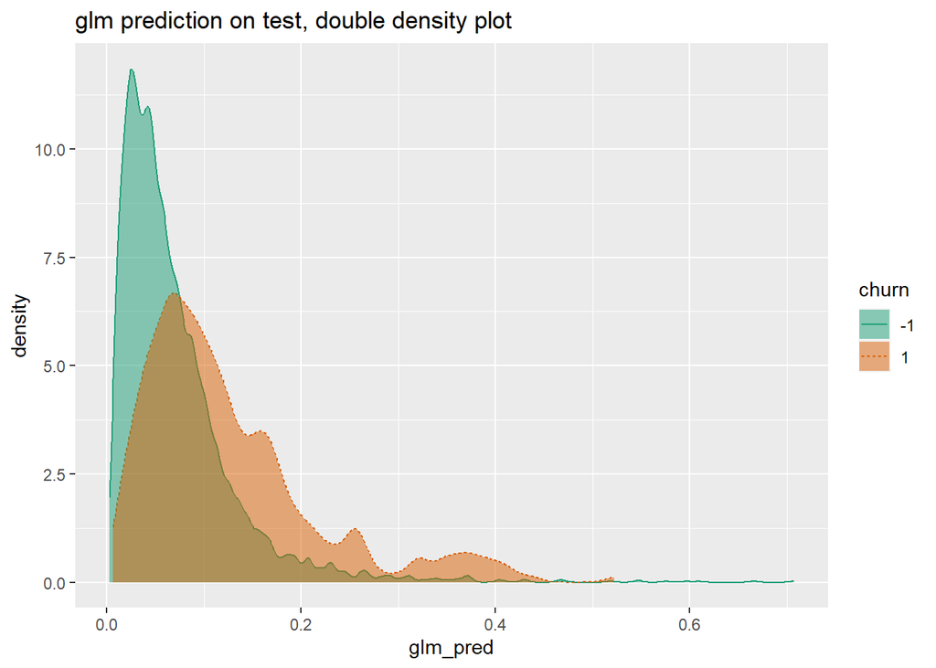

```r
WVPlots::DoubleDensityPlot(dTest_treated, "glm_pred", "churn",
                          "glm prediction on test, double density plot")
```

```r
# Le classificateur suivant est meilleur :

table(prediction = dTest_treated$glm_pred>0.15,
    truth = dTest$churn)
```

```
##           truth
## prediction   -1    1
##      FALSE 4247  266
##      TRUE   352  110
```

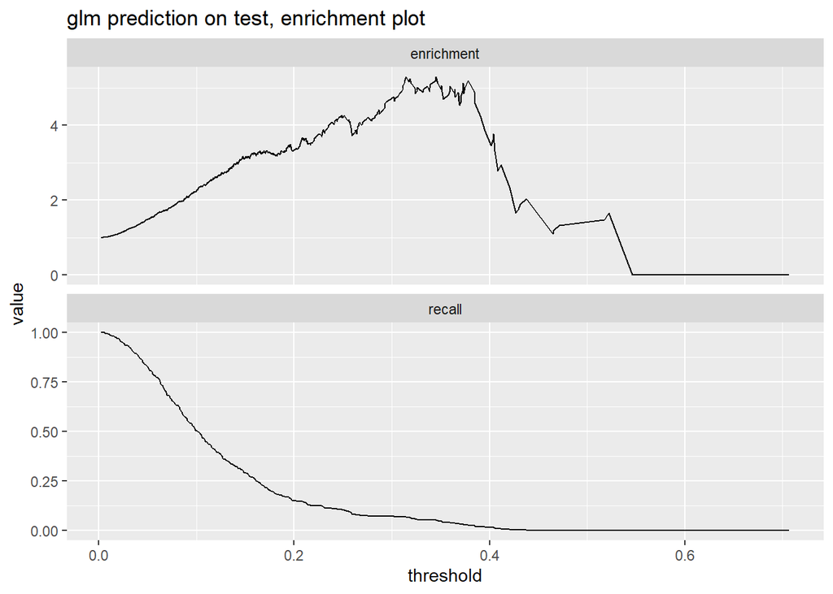

```r
WVPlots::PRTPlot(dTest_treated, "glm_pred", "churn",
                      "glm prediction on test, enrichment plot",
                      truthTarget = 1,
                      plotvars = c("enrichment", "recall"),
                      thresholdrange = c(0, 1.0))
```

## 5. Pré-traitement des données pour la régression

```r
auto_mpg <- readRDS('data/auto_mpg.RDS')
knitr::kable(head(auto_mpg))
```

| mpg | cylinders | displacement | horsepower | weight | acceleration | model_year | origin | car_name |
| --- | --- | --- | --- | --- | --- | --- | --- | --- |
| 18 | 8 | 307 | 130 | 3504 | 12.0 | 70 | 1 | “chevrolet chevelle malibu” |
| 15 | 8 | 350 | 165 | 3693 | 11.5 | 70 | 1 | “buick skylark 320” |
| 18 | 8 | 318 | 150 | 3436 | 11.0 | 70 | 1 | “plymouth satellite” |
| 16 | 8 | 304 | 150 | 3433 | 12.0 | 70 | 1 | “amc rebel sst” |
| 17 | 8 | 302 | 140 | 3449 | 10.5 | 70 | 1 | “ford torino” |
| 15 | 8 | 429 | 198 | 4341 | 10.0 | 70 | 1 | “ford galaxie 500” |

```r
library("wrapr")

vars <- c("cylinders", "displacement",
          "horsepower", "weight", "acceleration",
          "model_year", "origin")

f <- mk_formula("mpg", vars)

model <- lm(f, data = auto_mpg)

auto_mpg$prediction <- predict(model, newdata = auto_mpg)

str(auto_mpg[!complete.cases(auto_mpg), , drop = FALSE])
```

```
## 'data.frame':    6 obs. of  10 variables:
##  $ mpg         : num  25 21 40.9 23.6 34.5 23
##  $ cylinders   : num  4 6 4 4 4 4
##  $ displacement: num  98 200 85 140 100 151
##  $ horsepower  : num  NA NA NA NA NA NA
##  $ weight      : num  2046 2875 1835 2905 2320 ...
##  $ acceleration: num  19 17 17.3 14.3 15.8 20.5
##  $ model_year  : num  71 74 80 80 81 82
##  $ origin      : Factor w/ 3 levels "1","2","3": 1 1 2 1 2 1
##  $ car_name    : chr  "\"ford pinto\"" "\"ford maverick\"" "\"renault lecar deluxe\"" "\"ford mustang cobra\"" ...
##  $ prediction  : num  NA NA NA NA NA NA
```

```r
# Parce que le jeu de données avait des valeurs manquantes, le modèle n'a pas pu retourner une
# prédiction pour chaque ligne. Maintenant, nous allons réessayer, en utilisant vtreat
# pour pré-traiter les données:

library(vtreat)

cfe <- mkCrossFrameNExperiment(auto_mpg, vars, "mpg",verbose = FALSE)

treatment_plan <- cfe$treatments

auto_mpg_treated <- cfe$crossFrame

score_frame <- treatment_plan$scoreFrame

new_vars <- score_frame$varName

newf <- mk_formula("mpg", new_vars)

new_model <- lm(newf, data = auto_mpg_treated)

auto_mpg$prediction <- predict(new_model, newdata = auto_mpg_treated)

# maintenant une prédiction a été calculée pour chaque ligne :
str(auto_mpg[!complete.cases(auto_mpg), , drop = FALSE])
```

```
## 'data.frame':    6 obs. of  10 variables:
##  $ mpg         : num  25 21 40.9 23.6 34.5 23
##  $ cylinders   : num  4 6 4 4 4 4
##  $ displacement: num  98 200 85 140 100 151
##  $ horsepower  : num  NA NA NA NA NA NA
##  $ weight      : num  2046 2875 1835 2905 2320 ...
##  $ acceleration: num  19 17 17.3 14.3 15.8 20.5
##  $ model_year  : num  71 74 80 80 81 82
##  $ origin      : Factor w/ 3 levels "1","2","3": 1 1 2 1 2 1
##  $ car_name    : chr  "\"ford pinto\"" "\"ford maverick\"" "\"renault lecar deluxe\"" "\"ford mustang cobra\"" ...
##  $ prediction  : num  24.5 22.5 35 26 32.6 ...
```

## 6. Maîtriser le package “vtreat”

### 6.1 Les phases vtreat

Vtreat a 2 phases : la conception et l’application du plan de traitement.

### 6.2 Valeurs manquantes

```r
library(wrapr)

d <- build_frame(
          "x1" , "x2" , "x3", "y" |
          1 , "a" , 6 , 10 |
          NA_real_, "b" , 7 , 20 |
          3 , NA_character_, 8 , 30 )

knitr::kable(d)
```

| x1 | x2 | x3 | y |
| --- | --- | --- | --- |
| 1 | a | 6 | 10 |
| NA | b | 7 | 20 |
| 3 | NA | 8 | 30 |

```r
plan1 <- vtreat::design_missingness_treatment(d)

vtreat::prepare(plan1, d) %.>% knitr::kable(.)
```

| x1 | x1_isBAD | x2 | x3 | y |
| --- | --- | --- | --- | --- |
| 1 | 0 | a | 6 | 10 |
| 2 | 1 | b | 7 | 20 |
| 3 | 0 | *invalid* | 8 | 30 |

### 6.3 Variables indicatrices (ou one-hot encoding)

```r
d <- build_frame(
          "x1" , "x2" , "x3", "y" |
          1 , "a" , 6 , 10 |
          NA_real_, "b" , 7 , 20 |
          3 , NA_character_, 8 , 30 )

print(d)
```

```
##   x1   x2 x3  y
## 1  1    a  6 10
## 2 NA    b  7 20
## 3  3 <NA>  8 30
```

```r
plan2 <- vtreat::designTreatmentsZ(d,
              varlist = c("x1", "x2", "x3"),
              verbose = FALSE)

vtreat::prepare(plan2, d)
```

```
##   x1 x1_isBAD x3 x2_lev_NA x2_lev_x_a x2_lev_x_b
## 1  1        0  6         0          1          0
## 2  2        1  7         0          0          1
## 3  3        0  8         1          0          0
```

### 6.4 Variables d’impact

```r
d <- build_frame(
                  "x1" , "x2" , "x3", "y" |
                    1 , "a" , 6 , 10 |
                    NA_real_, "b" , 7 , 20 |
                    3 , NA_character_, 8 , 30 )

print(d)
```

```
##   x1   x2 x3  y
## 1  1    a  6 10
## 2 NA    b  7 20
## 3  3 <NA>  8 30
```

```r
# Voyons l'effet d'un simple exemple de prédiction numérique ou de régression:

plan3 <- vtreat::designTreatmentsN(d,
                varlist = c("x1", "x2", "x3"),
                outcomename = "y",
                codeRestriction = "catN",
                verbose = FALSE)

vtreat::prepare(plan3, d)
```

```
##   x2_catN  y
## 1     -10 10
## 2       0 20
## 3      10 30
```

```r
# La variable codée par impact se trouve dans la nouvelle colonne nommée x2_catN.
# Notez que dans la première ligne, il est de -10, car la valeur y est 10,
# ce qui est 10 en dessous de la valeur moyenne de y

# Le codage par impact pour les variables catégorielles est similaire sauf
# qu'il est exprimé en unité logarithmique

plan4 <- vtreat::designTreatmentsC(d,
              varlist = c("x1", "x2", "x3"),
              outcomename = "y",
              outcometarget = 20,
              codeRestriction = "catB",
              verbose = FALSE)

vtreat::prepare(plan4, d)
```

```
##     x2_catB  y
## 1 -8.517343 10
## 2  9.903538 20
## 3 -8.517343 30
```

### 6.5 Plan de traitement

Le code suivant illustre la structure d’un pla de traitement :

```r
class(plan4)
```

```
## [1] "treatmentplan"
```

```r
names(plan4)
```

```
## [1] "treatments"    "scoreFrame"    "outcomename"   "vtreatVersion"
## [5] "outcomeType"   "outcomeTarget" "meanY"         "splitmethod"
## [9] "fit_obj_id"
```

```r
plan4$scoreFrame
```

```
##   varName varMoves rsq       sig needsSplit extraModelDegrees origName code
## 1 x2_catB     TRUE   1 0.0506719       TRUE                 2       x2 catB
##   default_threshold recommended
## 1                 1        TRUE
```

### 6.6 Cross-frame

Le cross-frame est un élément trouvé dans la liste des objets retournés par les méthodes mkCrossFrame*Experiment (). C’est une innovation qui permet d’utiliser en toute sécurité les mêmes données à la fois pour le prétraitemnt et pour l’apprentissage d’un modèle. Sans cette méthode de validation croisée, il faut utiliser deux jeux de données disjoints

```r
set.seed(2019)
      d <- data.frame(
            x_bad = sample(letters, 100, replace = TRUE),
            y = rnorm(100),
            stringsAsFactors = FALSE
            )

      d$x_good <- ifelse(d$y > rnorm(100), "non-neg", "neg")
head(d)
```

```
##   x_bad          y  x_good
## 1     y -0.7603575 non-neg
## 2     j  0.4442418 non-neg
## 3     e  1.7386856 non-neg
## 4     m -0.7752029 non-neg
## 5     q -1.1825636     neg
## 6     x -0.3140285 non-neg
```

```r
cfe <- vtreat::mkCrossFrameNExperiment(d,
              varlist = c("x_bad", "x_good"),
              outcomename = "y",
              codeRestriction = "catN",
              minFraction = 2,
              verbose = FALSE)

plan6 <- cfe$treatments

training_data2 <- cfe$crossFrame

res2 <- vtreat::patch_columns_into_frame(d, training_data2)

head(res2)
```

```
##   x_bad  x_good  x_bad_catN x_good_catN          y
## 1     y non-neg  0.42026574   0.5754247 -0.7603575
## 2     j non-neg -1.47279169   0.4806320  0.4442418
## 3     e non-neg  0.07721550   0.5754247  1.7386856
## 4     m non-neg  0.04872723   0.4806320 -0.7752029
## 5     q     neg -0.34438675  -0.5256913 -1.1825636
## 6     x non-neg  0.00000000   0.5105871 -0.3140285
```

```r
sigr::wrapFTest(res2, "x_bad_catN", "y")
```

```
## [1] "F Test summary: (R2=-0.7385, F(1,98)=-41.63, p=n.s.)."
```

```r
sigr::wrapFTest(res2, "x_good_catN", "y")
```

```
## [1] "F Test summary: (R2=0.3038, F(1,98)=42.77, p<1e-05)."
```

```r
# Les tests F sur les données et les statistiques scoreFrame sont consistants :

plan6$scoreFrame
```

```
##       varName varMoves         rsq          sig needsSplit extraModelDegrees
## 1  x_bad_catN     TRUE 9.93962e-05 9.215776e-01       TRUE                25
## 2 x_good_catN     TRUE 3.25805e-01 5.631959e-10       TRUE                 1
##   origName code default_threshold recommended
## 1    x_bad catN               0.5       FALSE
## 2   x_good catN               0.5        TRUE
```

```r
#sigr :: wrapFTest () considère correctement x_bad_catN comme une variable de faible valeur.
```